# Final Project

Jun Zhang

3/1/2018

Our topic is: Is there a significant difference in income between men and women? Does the difference vary depending on other factors (e.g., education, marital status, criminal history, drug use, childhood household factors, profession, etc.)?

Let’s subset a data set from the original one and take a look at it first:

```r
library(plyr)
library(dplyr)
```

```r
library(ggplot2)
library(MASS)
library(knitr)
library(reshape)
library(prettydoc)
```

```r
nlsy <- read.csv("http://www.andrew.cmu.edu/user/achoulde/94842/final_project/nlsy79/nlsy79_income.csv", header=TRUE)
nlsy <- subset(nlsy,
                     select = c("R0214800", "R3279401", "R0000700", "T4113000", "R0214700", "R7007000", "R0217502")
                      )
colnames(nlsy) <- c("sex", "income", "country", "education", "race", "marital.status", "family.size")
nlsy <- nlsy[nlsy$income >= 0, ]
```

```r
nlsy <- transform(nlsy,
                  sex = as.factor(mapvalues(sex, c(1, 2), c("Male", "Female"))),
                  country = as.factor(mapvalues(country, c(1, 2), c("inside.US", "outside.US"))),
                  race = as.factor(mapvalues(race, 1:3, c("Hispanic", "Black", "Other"))),
                  marital.status = as.factor(mapvalues(marital.status, c(0, 1, 2, 3, 6), c("Never.Married", "Married", "Separated", "Divorced", "Widowed"))),
                  education = as.factor(mapvalues(education, c(0, 93, 94, 1, 2, 3, 4, 5, 6, 7, 8, 9, 10, 11, 12, 13, 14, 15, 16, 17, 18, 19, 20, 95), c("<=6th", "<=6th", "<=6th", "<=6th", "<=6th", "<=6th", "<=6th", "<=6th", "<=6th", "7th-8th", "7th-8th", "9th", "10th", "11th", "12th", "1st year college", "2nd year college", "3rd year college", "4th year college", "5th year college", "6th year college", "7th year college", "8th year college", "ungraded")))
                  )
str(nlsy)
```

```
## 'data.frame':    10199 obs. of  7 variables:
##  $ sex           : Factor w/ 2 levels "Female","Male": 1 1 1 2 2 1 2 1 2 2 ...
##  $ income        : int  20000 6000 0 23000 0 17000 30000 4000 74283 40000 ...
##  $ country       : Factor w/ 3 levels "-3","inside.US",..: 3 2 2 2 2 2 2 2 2 2 ...
##  $ education     : Factor w/ 15 levels "-5","<=6th","10th",..: 5 5 1 9 1 7 7 1 1 1 ...
##  $ race          : Factor w/ 3 levels "Black","Hispanic",..: 3 3 3 3 3 3 3 3 3 3 ...
##  $ marital.status: Factor w/ 7 levels "-3","-5","Divorced",..: 4 4 2 4 3 3 4 2 5 6 ...
##  $ family.size   : int  5 5 5 4 3 3 6 3 3 5 ...
```

```r
summary(nlsy)
```

```
##      sex           income            country                education
##  Female:5206   Min.   :    0   -3        :   1   -5              :3330
##  Male  :4993   1st Qu.: 3000   inside.US :9521   12th            :2975
##                Median :13500   outside.US: 677   4th year college: 827
##                Mean   :15418                     2nd year college: 701
##                3rd Qu.:23000                     1st year college: 613
##                Max.   :74283                     3rd year college: 361
##                                                  (Other)         :1392
##        race            marital.status  family.size
##  Black   :2637   -3           :   2   Min.   : 1.00
##  Hispanic:1697   -5           :2624   1st Qu.: 3.00
##  Other   :5865   Divorced     :1161   Median : 4.00
##                  Married      :4438   Mean   : 4.55
##                  Never.Married:1465   3rd Qu.: 6.00
##                  Separated    : 446   Max.   :15.00
##                  Widowed      :  63
```

The subsetted dataset contains 10199 valid respondents, including 5206 female respondents and 4993 male respondents.There are 67 attributes such as sex, income, race. I chose 5 independent variables, including country of birth, education level, race, marital status, and family size, to see if they affect the income gap between male and female. Above is the summary of dataset with 5 variables I chose.

The data set is top-coded. The top 2% of income values are replaced with the group average. That means we cannot know the standard deviation for the top 2% respondents. So the model may not be suitable to explain the income gap among high-income respondents. But I still keep the data in the following analysis.

You can see that I reset each column’s name so that the variable names could be more informative. For the education variable, for level “none”, “pre-kindergarten”, “1st grade”, “2nd grade”, “3rd grade”, “4th grade”, “5th grade”, “6th grade”, I changed these names to “<=6th”; for level “7th grade”, “8th grade”, I changed these names to “7th-8th”. Below is a sample of the data set.

```r
head(nlsy)
```

```
##      sex income    country        education  race marital.status
## 2 Female  20000 outside.US             12th Other        Married
## 3 Female   6000  inside.US             12th Other        Married
## 4 Female      0  inside.US               -5 Other             -5
## 6   Male  23000  inside.US 4th year college Other        Married
## 7   Male      0  inside.US               -5 Other       Divorced
## 8 Female  17000  inside.US 2nd year college Other       Divorced
##   family.size
## 2           5
## 3           5
## 4           5
## 6           4
## 7           3
## 8           3
```

From the boxplot below, you can see that the median total income for male is higher than the median total income for female. So female is associated with low income. Besides, the full range of variation (upper inner fence - lower inner fence) for male is wider that that for female. Notice that the outliers for female are more than the outliers for male, and lower quartile Q1 for female respondents reaches 0.

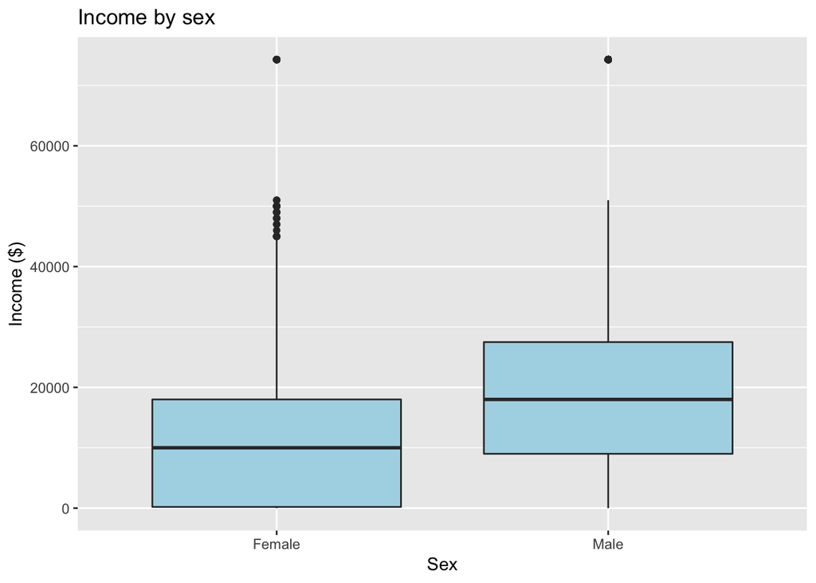

```r
qplot(x = sex, y = income,
      geom = "boxplot", data = nlsy,
      xlab = "Sex",
      ylab = "Income ($)",
      main = "Income by sex",
      fill = I("lightblue"))
```

So what can we learn from the data set? I constructed bar charts first and ran regression models later. For each variable, I will construct 2 bar charts, one is used to see if there is a significant difference in income between men and women holding the certain independent variable constant, the other is used to see if the income gap is statistically significant for certain independent variable.

1. Bar Charts

Let’s take a look at the average income of men and women.

As we can see in the bar chart below, the average income of men is approximately $8125 more than that of women. Besides, the 95% confidence intervals do not overlap so the probability that this difference is significant is extremely high.

```r
income1 <- ddply(nlsy, ~ sex, summarize,
      mean.income = mean(income),
      lower = t.test(income)$conf.int[1],
      upper = t.test(income)$conf.int[2]
      )
```

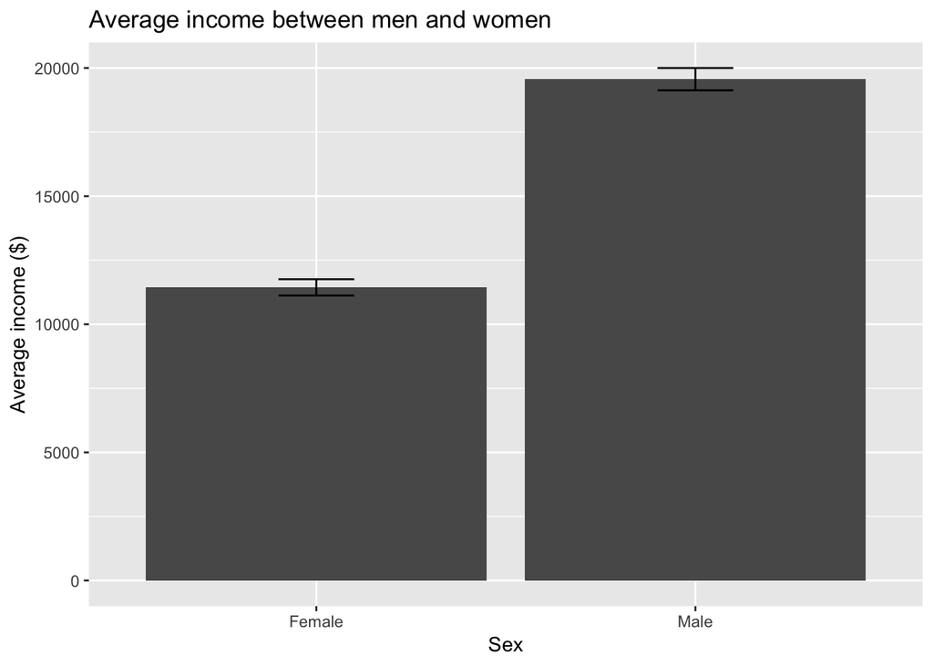

```r
ggplot(data = income1, aes(x = sex, y = mean.income)) +
  geom_bar(stat = "identity") +
  xlab("Sex") +
  ylab("Average income ($)") +
  ggtitle("Average income between men and women") +
  guides(fill = FALSE) +
  geom_errorbar(aes(ymin=lower, ymax=upper),
                width=.2,
                position=position_dodge(0.9))
```

More detailed data are shown in the markdown table below:

```r
tbl.round <- with(nlsy, round(tapply(income, INDEX = list(sex), FUN = mean)))
kable(tbl.round, format = "markdown", col.names = "income")
```

|  | income |
| --- | --- |
| Female | 11441 |
| Male | 19566 |

Let’s see how other variables affect the income difference between men and women:

(1)Race

Holding race constant, is there a significant difference in income between men and women? To answer this question, I constructed the bar chart below and did the t test. We can see that there a significant difference in income between men and women since the error bars do not overlap. Besides, for both men and women, other group earn the most, followed by hispanic group, and then black group.

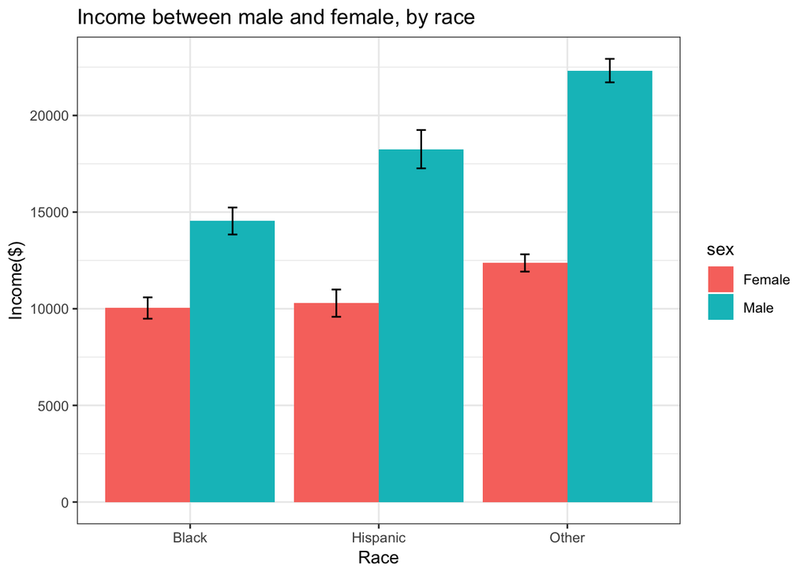

```r
gap.data.conf <- ddply(nlsy, ~ race + sex, summarize,
                       average.income = mean(income),
                       upper = t.test(income)$conf.int[1],
                       lower = t.test(income)$conf.int[2])

gap.data.conf <- transform(gap.data.conf,
                           race = reorder(race, average.income))

ggplot(data = gap.data.conf, aes(x = race, y = average.income, fill = sex
                            )) +
  geom_bar(position="dodge",stat = "identity") +
  xlab("Race") +
  ylab("Income($)") +
  ggtitle("Income between male and female, by race") +
  geom_errorbar(aes(ymax = upper, ymin = lower), width = 0.1, size = 0.5, position=position_dodge(0.9)) +
  theme(text = element_text(size=12)) + theme_bw()
```

Let’s compute the income gap between male and female, and take a look at the income gap by race.

As we can see in the bar chart below, the difference in average income between male and female is the biggest among other group, followed by hispanic group, and then black group. We can also know that race significantly affect the income gap between men and women since the error bars are not overlapped.

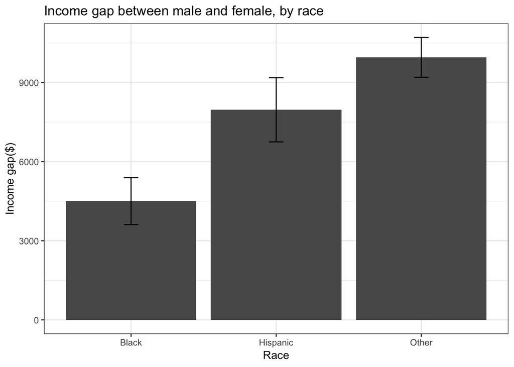

```r
gap.data.conf1 <- ddply(nlsy, ~ race , summarize,
                       difference = mean(income[sex == "Male"], na.rm = TRUE) -
                       mean(income[sex == "Female"], na.rm = TRUE),
                       upper = t.test(income[sex == "Male"], income[sex == "Female"])$conf.int[1],
                       lower = t.test(income[sex == "Male"], income[sex == "Female"])$conf.int[2])

gap.data.conf1 <- transform(gap.data.conf1,
                           race = reorder(race, difference))

ggplot(data = gap.data.conf1, aes(x = race, y = difference
                            )) +
  geom_bar(position="dodge",stat = "identity") +
  xlab("Race") +
  ylab("Income gap($)") +
  ggtitle("Income gap between male and female, by race") +
  geom_errorbar(aes(ymax = upper, ymin = lower), width = 0.1, size = 0.5, position=position_dodge(0.9)) +
  theme(text = element_text(size=12)) + theme_bw()
```

More detailed data are shown in the markdown table below:

```r
tbl.round <- with(nlsy, round(tapply(income, INDEX = list(sex, race), FUN = mean)))
kable(tbl.round, format = "markdown")
```

|  | Black | Hispanic | Other |
| --- | --- | --- | --- |
| Female | 10038 | 10289 | 12369 |
| Male | 14539 | 18255 | 22321 |

(2)Country

```r
table(nlsy$country)
```

```
##
##         -3  inside.US outside.US
##          1       9521        677
```

```r
nlsy$country[nlsy$country == -3] <- NA
nlsy2 <- nlsy
nlsy2 <- nlsy2[-c(3730), ]
nlsy2$country <- factor(nlsy2$country)
table(nlsy2$country)
```

```
##
##  inside.US outside.US
##       9521        677
```

From the first table above, we can see that in the original data set, there’s one “-3” in column country. It’s an invalid skip. Thus, I mapped this negative value to missing (NA) and removed it from the dataset. Since there’s only one row, it will not have great influence on the whole dataset and my analysis. The second table above is the updated one.

Let’s take a look at the data, we can see that the majority of respondents are from the United States. Holding country constant, is there a significant difference in income between men and women? From the bar chart below, we can see that there a significant difference in income between men and women since the error bars do not overlap. Besides, for both men and women, respondents from outside of the U.S. earn more than U.S. citizens.

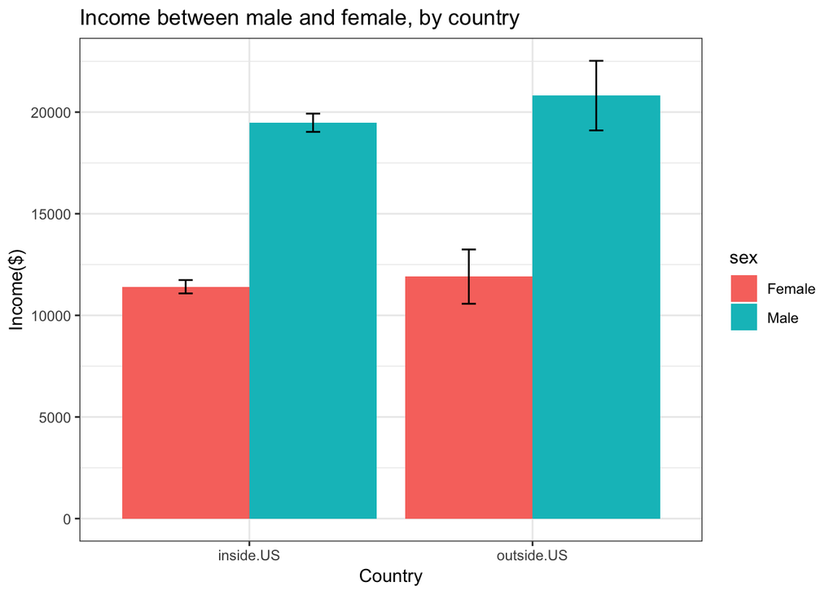

```r
gap.data.conf2 <- ddply(nlsy2, ~ country + sex, summarize,
                       average.income = mean(income),
                       upper = t.test(income)$conf.int[1],
                       lower = t.test(income)$conf.int[2])

gap.data.conf2 <- transform(gap.data.conf2,
                           country = reorder(country, average.income))

ggplot(data = gap.data.conf2, aes(x = country, y = average.income, fill = sex)) +
  geom_bar(position="dodge",stat = "identity") +
  xlab("Country") +
  ylab("Income($)") +
  ggtitle("Income between male and female, by country") +
  geom_errorbar(aes(ymax = upper, ymin = lower), width = 0.1, size = 0.5, position=position_dodge(0.9)) +
  theme(text = element_text(size=12)) + theme_bw()
```

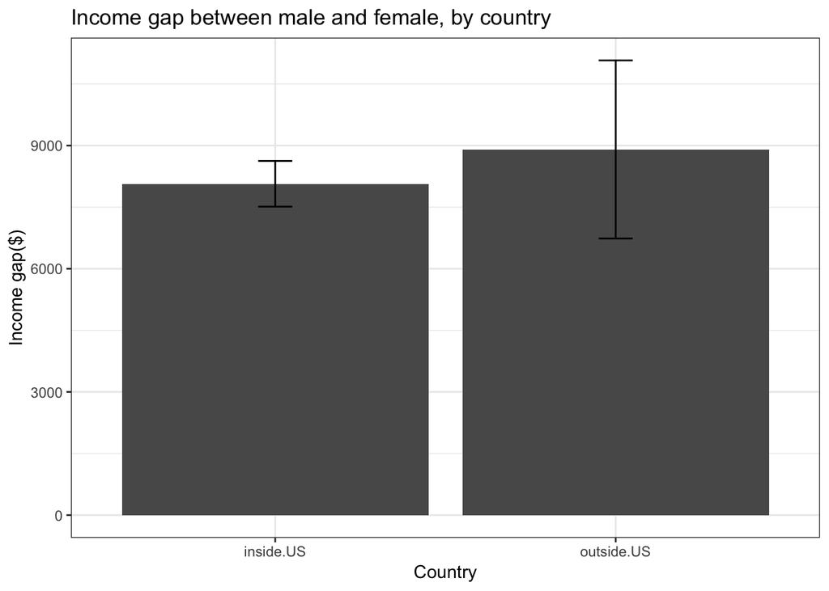

```r
gap.data.conf3 <- ddply(nlsy2, ~ country, summarize,
                       difference = mean(income[sex == "Male"], na.rm = TRUE) -
                       mean(income[sex == "Female"], na.rm = TRUE),
                       upper = t.test(income[sex == "Male"], income[sex == "Female"])$conf.int[1],
                       lower = t.test(income[sex == "Male"], income[sex == "Female"])$conf.int[2])

gap.data.conf3 <- transform(gap.data.conf3,
                           country = reorder(country, difference))

ggplot(data = gap.data.conf3, aes(x = country, y = difference)) +
  geom_bar(position="dodge",stat = "identity") +
  xlab("Country") +
  ylab("Income gap($)") +
  ggtitle("Income gap between male and female, by country") +
  geom_errorbar(aes(ymax = upper, ymin = lower), width = 0.1, size = 0.5, position=position_dodge(0.9)) +
  theme(text = element_text(size=12)) + theme_bw()
```

More detailed data are shown in the markdown table below:

```r
tbl.round <- with(nlsy2, round(tapply(income, INDEX = list(sex, country), FUN = mean)))

kable(tbl.round, format = "markdown")
```

|  | inside.US | outside.US |
| --- | --- | --- |
| Female | 11409 | 11907 |
| Male | 19478 | 20813 |

(3)Education

```r
table(nlsy2$education)
```

```
##
##               -5            <=6th             10th             11th
##             3330               50              142              179
##             12th 1st year college 2nd year college 3rd year college
##             2975              613              701              361
## 4th year college 5th year college 6th year college 7th year college
##              827              202              270              115
##          7th-8th 8th year college              9th
##              128              151              154
```

```r
nlsy2$education[nlsy2$education == -5] <- NA
table(nlsy2$education)
```

```
##
##               -5            <=6th             10th             11th
##                0               50              142              179
##             12th 1st year college 2nd year college 3rd year college
##             2975              613              701              361
## 4th year college 5th year college 6th year college 7th year college
##              827              202              270              115
##          7th-8th 8th year college              9th
##              128              151              154
```

From the first table above, we can see that in the original data set, there’re 3330 “-5”. It means non-interview. So, I mapped “-5” to NA, as is shown in the second table above.

Because 3330 is not a small number, I can’t remove the data without careful consideration. So I keep the data. But when I studied how the education level will affect the income gap between male and female, I only used the valid levels to do the analysis.

Holding education level constant, is there a significant difference in income between men and women? From the bar chart below we can see that in general, there’s a significant difference in income between men and women since the error bars do not overlap. Besides, in general, as education level increases, the income of both female and male respondents increases.

Note that the sample size for 12th grade have much larger samples.

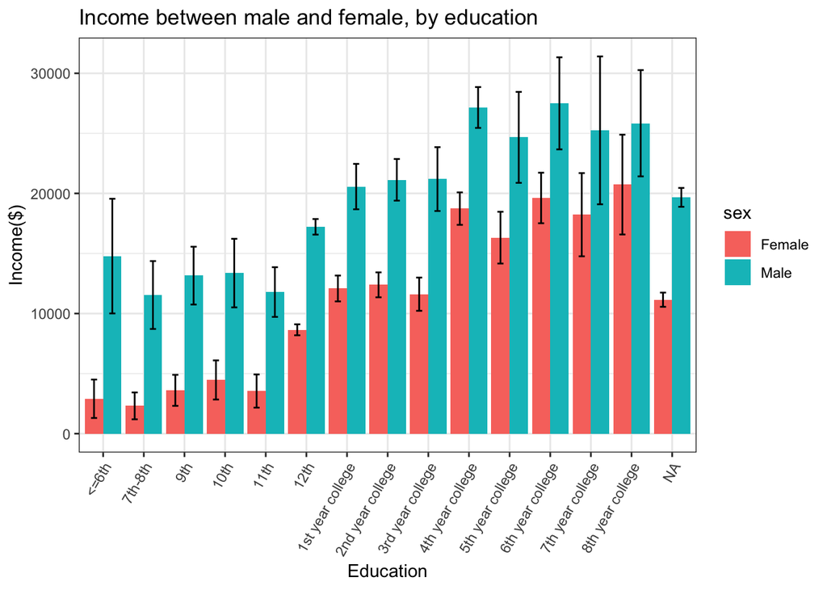

```r
nlsy2$education <- factor(nlsy2$education, levels = c("<=6th", "7th-8th", "9th", "10th", "11th", "12th", "1st year college", "2nd year college", "3rd year college", "4th year college", "5th year college", "6th year college", "7th year college", "8th year college", "ungraded"))
gap.data.conf4 <- ddply(nlsy2, ~ education + sex, summarize,
                       average.income = mean(income),
                       upper = t.test(income)$conf.int[1],
                       lower = t.test(income)$conf.int[2])

ggplot(data = gap.data.conf4, aes(x = education, y = average.income, fill = sex)) +
  geom_bar(position="dodge", stat = "identity") +
  xlab("Education") +
  ylab("Income($)") +
  ggtitle("Income between male and female, by education") +
  geom_errorbar(aes(ymax = upper, ymin = lower), width = 0.3, size = 0.5, position=position_dodge(0.9)) + theme_bw() +
  theme(axis.text.x  = element_text(angle=60, vjust = 1,
                                    hjust = 1))
```

So, does education level affect the income gap between men and women? From the bar chart below, we can see that in general, as education level increases, income gap between men and women decreases. However, education does not significantly affect the income gap between men and women since the error bars overlap.

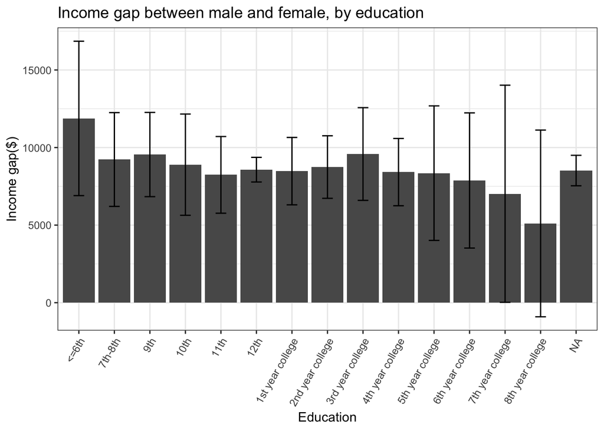

```r
gap.data.conf5 <- ddply(nlsy2, ~ education , summarize,
                       difference = mean(income[sex == "Male"], na.rm = TRUE) -
                       mean(income[sex == "Female"], na.rm = TRUE),
                       upper = t.test(income[sex == "Male"], income[sex == "Female"])$conf.int[1],
                       lower = t.test(income[sex == "Male"], income[sex == "Female"])$conf.int[2])

ggplot(data = gap.data.conf5, aes(x = education, y = difference)) +
  geom_bar(position="dodge", stat = "identity") +
  xlab("Education") +
  ylab("Income gap($)") +
  ggtitle("Income gap between male and female, by education") +
  geom_errorbar(aes(ymax = upper, ymin = lower), width = 0.3, size = 0.5, position=position_dodge(0.9)) + theme_bw() +
  theme(axis.text.x  = element_text(angle=60, vjust = 1,
                                    hjust = 1))
```

More detailed data are shown in the markdown table below:

```r
tbl.round <- with(nlsy2, round(tapply(income, INDEX = list(sex, education), FUN = mean)))
kable(tbl.round, format = "markdown")
```

|  | <=6th | 7th-8th | 9th | 10th | 11th | 12th | 1st year college | 2nd year college | 3rd year college | 4th year college | 5th year college | 6th year college | 7th year college | 8th year college | ungraded |
| --- | --- | --- | --- | --- | --- | --- | --- | --- | --- | --- | --- | --- | --- | --- | --- |
| Female | 2903 | 2313 | 3607 | 4471 | 3549 | 8644 | 12087 | 12389 | 11608 | 18734 | 16316 | 19620 | 18227 | 20734 | NA |
| Male | 14781 | 11541 | 13156 | 13367 | 11788 | 17218 | 20566 | 21131 | 21192 | 27151 | 24666 | 27498 | 25248 | 25841 | NA |

(4)Marital status

```r
table(nlsy$marital.status)
```

```
##
##            -3            -5      Divorced       Married Never.Married
##             2          2624          1161          4438          1465
##     Separated       Widowed
##           446            63
```

```r
nlsy2 <- nlsy
nlsy2$marital.status[nlsy2$marital.status == -3] <- NA
nlsy2$marital.status[nlsy2$marital.status == -5] <- NA
table(nlsy2$marital.status)
```

```
##
##            -3            -5      Divorced       Married Never.Married
##             0             0          1161          4438          1465
##     Separated       Widowed
##           446            63
```

From the first table above, we can see that in the original data set, there’re 2624 “-5” and 2 “-3”. “-3” is invalid skip, and “-5” means non-interview. So I map both “-3” and “-5” to missing value, as is shown in the second table above. Since there are 2626 invalid values in total, I can’t remove them without careful consideration as well. So I keep the data. However, when I studied how the marital status variable will affect the income gap between male and female, I only used the rows which do not contain missing value.

Holding marital status constant, is there a significant difference in income between men and women? From the bar chart below, we can see that in general, there’s a significant difference in income between men and women since the error bars do not overlap. Besides, for both men and women, married respondents earn the most, followed by divorced respondents. Separated women and never married men earn the least.

Notice that the majority of respondents are either married, never married, or divorced.

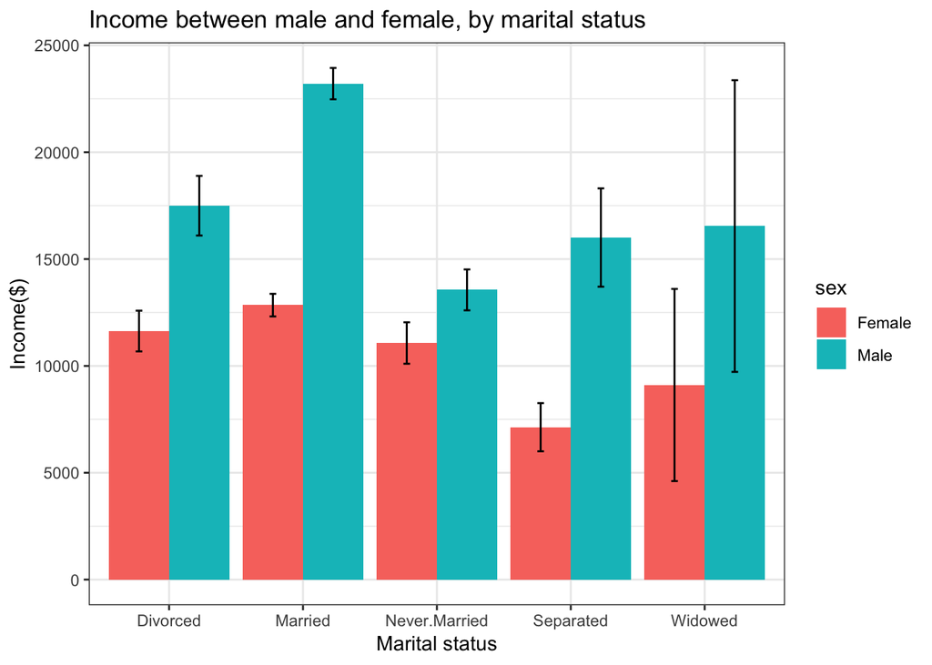

```r
nlsy3 <- subset(nlsy2, subset = education %in% c("<=6th", "7st-9th","10th", "11th", "12th", "1st year college", "2nd year college", "3rd year college", "4th year college", "5th year college", "6th year college", "7th year college", "8th year college"))
nlsy4 <- subset(nlsy3, subset = marital.status %in% c("Never.Married", "Married", "Separated", "Divorced", "Widowed"))
nlsy4$marital.status = factor(nlsy4$marital.status)

gap.data.conf6 <- ddply(nlsy4, ~ marital.status + sex, summarize,
                       average.income = mean(income),
                       upper = t.test(income)$conf.int[1],
                       lower = t.test(income)$conf.int[2])

ggplot(data = gap.data.conf6, aes(x = marital.status, y = average.income, fill = sex)) +
  geom_bar(position="dodge", stat = "identity") +
  xlab("Marital status") +
  ylab("Income($)") +
  ggtitle("Income between male and female, by marital status") +
  geom_errorbar(aes(ymax = upper, ymin = lower), width = 0.1, size = 0.5, position=position_dodge(0.9)) +
  theme(text = element_text(size=12)) + theme_bw()
```

So, does marital status affect the income gap between men and women? From the bar chart below, we can see that the married group has the largest income gap between male and female, followed by separated group, widowed group, divorced group, and then never married group. Notice that for married, divorced, separated, and never married respondents, marital status significantly affect the income gap between men and women.

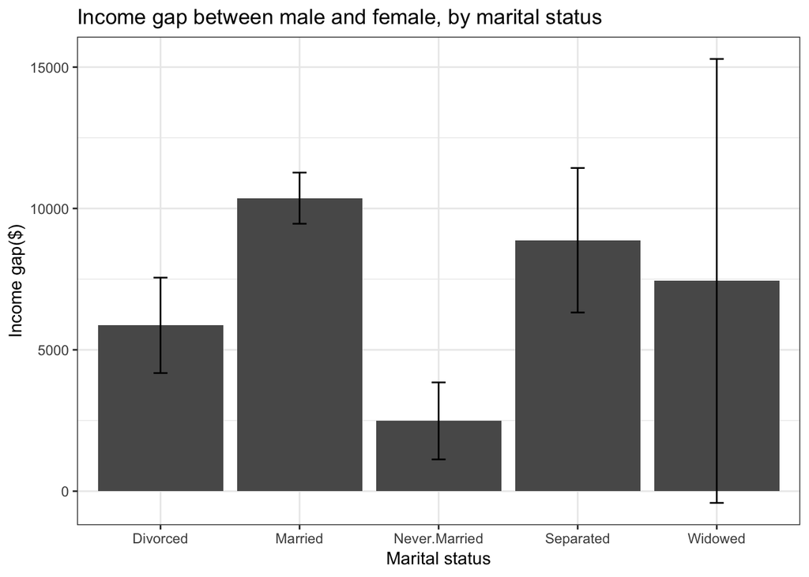

```r
gap.data.conf7 <- ddply(nlsy4, ~ marital.status, summarize,
                       difference = mean(income[sex == "Male"], na.rm = TRUE) -
                       mean(income[sex == "Female"], na.rm = TRUE),
                       upper = t.test(income[sex == "Male"], income[sex == "Female"])$conf.int[1],
                       lower = t.test(income[sex == "Male"], income[sex == "Female"])$conf.int[2])

ggplot(data = gap.data.conf7, aes(x = marital.status, y = difference)) +
  geom_bar(position="dodge", stat = "identity") +
  xlab("Marital status") +
  ylab("Income gap($)") +
  ggtitle("Income gap between male and female, by marital status") +
  geom_errorbar(aes(ymax = upper, ymin = lower), width = 0.1, size = 0.5, position=position_dodge(0.9)) +
  theme(text = element_text(size=12)) + theme_bw()
```

More detailed data are shown in the markdown table below:

```r
tbl.round <- with(nlsy4, round(tapply(income, INDEX = list(sex, marital.status), FUN = mean)))
kable(tbl.round, format = "markdown")
```

|  | Divorced | Married | Never.Married | Separated | Widowed |
| --- | --- | --- | --- | --- | --- |
| Female | 11632 | 12845 | 11072 | 7132 | 9107 |
| Male | 17498 | 23210 | 13558 | 16007 | 16544 |

(5)Family size

Notice that when the family size is 13, average income of women is higher than that of men.

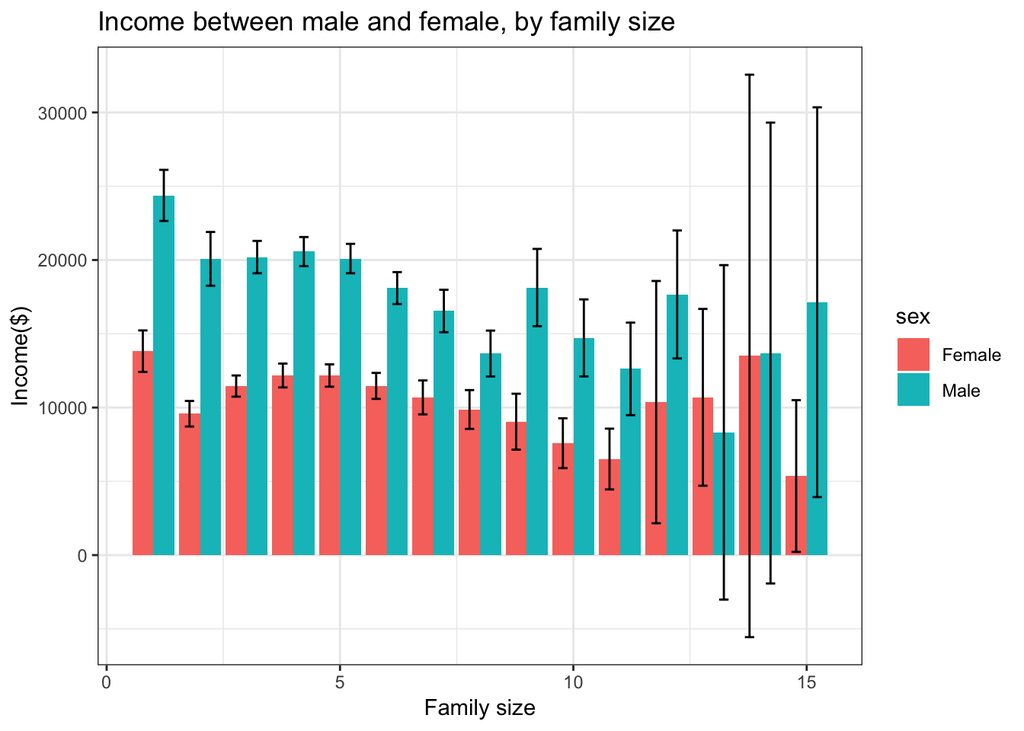

```r
gap.data.conf8 <- ddply(nlsy2, ~ family.size + sex, summarize,
                       average.income = mean(income),
                       upper = t.test(income)$conf.int[1],
                       lower = t.test(income)$conf.int[2])

ggplot(data = gap.data.conf8, aes(x = family.size, y = average.income, fill = sex)) +
  geom_bar(position="dodge",stat = "identity") +
  xlab("Family size") +
  ylab("Income($)") +
  ggtitle("Income between male and female, by family size") +
  geom_errorbar(aes(ymax = upper, ymin = lower), width = 0.4, size = 0.5, position=position_dodge(0.9)) +
  theme(text = element_text(size=12)) +
  theme_bw()
```

From the graph below, we can see that in general, family size does not significantly affect the income gap between men and women.

We can also see that the standard deviation for 4 groups (family size is 12, 13, 14, 15) is very high and the confidence intervals go below 0. That means for these 4 groups, some women earn more than men.

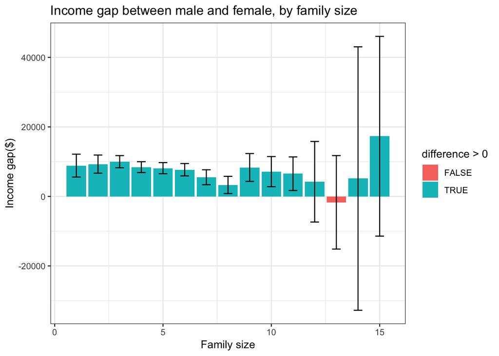

```r
gap.data.conf9 <- ddply(nlsy4, ~ family.size, summarize,
                       difference = mean(income[sex == "Male"], na.rm = TRUE) -
                       mean(income[sex == "Female"], na.rm = TRUE),
                       upper = t.test(income[sex == "Male"], income[sex == "Female"])$conf.int[1],
                       lower = t.test(income[sex == "Male"], income[sex == "Female"])$conf.int[2])

ggplot(data = gap.data.conf9, aes(x = family.size, y = difference, fill= difference > 0)) +
  geom_bar(position="dodge",stat = "identity") +
  xlab("Family size") +
  ylab("Income gap($)") +
  ggtitle("Income gap between male and female, by family size") +
  geom_errorbar(aes(ymax = upper, ymin = lower), width = 0.4, size = 0.5, position=position_dodge(0.9)) +
  theme(text = element_text(size=12)) +
  theme_bw()
```

More detailed data are shown in the markdown table below:

```r
tbl.round <- with(nlsy4, round(tapply(income, INDEX = list(sex, family.size), FUN = mean)))
kable(tbl.round, format = "markdown")
```

|  | 1 | 2 | 3 | 4 | 5 | 6 | 7 | 8 | 9 | 10 | 11 | 12 | 13 | 14 | 15 |
| --- | --- | --- | --- | --- | --- | --- | --- | --- | --- | --- | --- | --- | --- | --- | --- |
| Female | 13098 | 10738 | 11814 | 12909 | 12876 | 11804 | 11524 | 10492 | 10026 | 7355 | 6744 | 12117 | 12105 | 13500 | 4267 |
| Male | 21959 | 20034 | 21812 | 21338 | 20999 | 19486 | 17037 | 13797 | 18355 | 14487 | 13277 | 16333 | 10400 | 18640 | 21578 |

From the analysis above, we can see that there’s a significant difference in income between men and women. However, education, country, and family size do not significantly affect the income gap.

By looking at whether the error bars overlap, we compare the average income and its difference between men and women. T test is used to compare means of variables, and now I want to compare variation between different variables.

So, I ran another model – regression model. I also want to figure out the best linear regression model, that is, which variables I choose will have significant impact on the income gap between men and women.

After I ran the basic regression model (what impact does sex have on income), I found that male respondents earn on average $8125.1 more than female respondents, and it’s statistically significant at 0.05 level because P value is less than 2e-16.

```r
nlsy2.lm <- lm(income ~ sex, data = nlsy2)
summary(nlsy2.lm)
```

```
##
## Call:
## lm(formula = income ~ sex, data = nlsy2)
##
## Residuals:
##    Min     1Q Median     3Q    Max
## -19566 -11066  -1566   7434  62842
##
## Coefficients:
##             Estimate Std. Error t value Pr(>|t|)
## (Intercept)  11440.6      191.3   59.80   <2e-16 ***
## sexMale       8125.1      273.4   29.72   <2e-16 ***
## ---
## Signif. codes:  0 '***' 0.001 '**' 0.01 '*' 0.05 '.' 0.1 ' ' 1
##
## Residual standard error: 13800 on 10197 degrees of freedom
## Multiple R-squared:  0.0797, Adjusted R-squared:  0.07961
## F-statistic: 883.1 on 1 and 10197 DF,  p-value: < 2.2e-16
```

```r
options(scipen=4)
kable(summary(nlsy2.lm)$coef, format = 'markdown')
```

|  | Estimate | Std. Error | t value | Pr(>\|t\|) |
| --- | --- | --- | --- | --- |
| (Intercept) | 11440.650 | 191.3100 | 59.80162 | 0 |
| sexMale | 8125.124 | 273.4235 | 29.71626 | 0 |

2. Linear Regression

It seems that except for education:1st year college, education:2nd year college, education:3rd year college,marital.status:widowed, other coefficients are statistically significant.

```r
nlsy2.lm <- lm(income ~ ., data = nlsy2)
summary(nlsy2.lm)
```

```
##
## Call:
## lm(formula = income ~ ., data = nlsy2)
##
## Residuals:
##    Min     1Q Median     3Q    Max
## -29851  -8464  -1148   6665  66772
##
## Coefficients:
##                             Estimate Std. Error t value Pr(>|t|)
## (Intercept)                  9419.68     667.66  14.108  < 2e-16 ***
## sexMale                      8491.50     296.57  28.632  < 2e-16 ***
## countryoutside.US            2277.55     642.74   3.544 0.000397 ***
## education<=6th              -8276.53    2075.78  -3.987 6.75e-05 ***
## education10th               -5886.80    1184.22  -4.971 6.81e-07 ***
## education11th               -6780.04    1077.25  -6.294 3.27e-10 ***
## education12th               -2446.86     452.08  -5.412 6.41e-08 ***
## education1st year college     755.93     650.84   1.161 0.245488
## education2nd year college    1086.78     624.25   1.741 0.081736 .
## education3rd year college     776.68     790.17   0.983 0.325679
## education4th year college    6496.51     597.22  10.878  < 2e-16 ***
## education5th year college    3956.38     983.43   4.023 5.80e-05 ***
## education6th year college    6739.30     885.79   7.608 3.12e-14 ***
## education7th year college    4843.25    1262.08   3.838 0.000125 ***
## education7th-8th            -8060.31    1247.81  -6.460 1.12e-10 ***
## education8th year college    6508.04    1123.68   5.792 7.25e-09 ***
## education9th                -6611.68    1132.01  -5.841 5.42e-09 ***
## raceHispanic                 1483.17     459.01   3.231 0.001238 **
## raceOther                    3515.54     362.61   9.695  < 2e-16 ***
## marital.statusMarried        2072.60     425.54   4.871 1.14e-06 ***
## marital.statusNever.Married -1909.68     509.62  -3.747 0.000180 ***
## marital.statusSeparated     -1811.69     714.80  -2.535 0.011280 *
## marital.statusWidowed        1862.93    1653.72   1.127 0.259987
## family.size                  -194.00      67.38  -2.879 0.004000 **
## ---
## Signif. codes:  0 '***' 0.001 '**' 0.01 '*' 0.05 '.' 0.1 ' ' 1
##
## Residual standard error: 12750 on 7548 degrees of freedom
##   (2627 observations deleted due to missingness)
## Multiple R-squared:  0.2004, Adjusted R-squared:  0.198
## F-statistic: 82.25 on 23 and 7548 DF,  p-value: < 2.2e-16
```

```r
options(scipen=4)
```

(1)Race

Let’s add an interaction between sex and race. The regression below will help us compare the interaction between race and sex and evaluate how that affects the income. For example, we can see that, holding other variables constant, hispanic men tend to earn $3287.7 more than black men. However, I found that coefficient race:hispanic and race:other is not significant since its p value is greater than 0.05, but the coefficient sexMale:racehispanic and exMale:raceother are significant at 0.05 level. We can conclude that race is significant conditional on the inclusion of the interaction variable (sex) in the model.

```r
nlsy2.lm.interact1 <- lm(income ~ . + sex * race , data = nlsy2)
summary(nlsy2.lm.interact1)
```

```
##
## Call:
## lm(formula = income ~ . + sex * race, data = nlsy2)
##
## Residuals:
##    Min     1Q Median     3Q    Max
## -30960  -8574  -1314   6673  65257
##
## Coefficients:
##                             Estimate Std. Error t value Pr(>|t|)
## (Intercept)                 11172.27     703.98  15.870  < 2e-16 ***
## sexMale                      5123.55     535.92   9.560  < 2e-16 ***
## countryoutside.US            2217.93     640.47   3.463 0.000537 ***
## education<=6th              -8291.17    2069.23  -4.007 6.21e-05 ***
## education10th               -5854.24    1179.85  -4.962 7.13e-07 ***
## education11th               -6681.56    1073.09  -6.226 5.03e-10 ***
## education12th               -2446.12     450.30  -5.432 5.74e-08 ***
## education1st year college     648.57     648.43   1.000 0.317237
## education2nd year college     928.56     622.13   1.493 0.135594
## education3rd year college     639.18     787.27   0.812 0.416880
## education4th year college    6381.71     595.10  10.724  < 2e-16 ***
## education5th year college    3892.63     979.62   3.974 7.14e-05 ***
## education6th year college    6755.34     882.37   7.656 2.16e-14 ***
## education7th year college    4798.61    1257.16   3.817 0.000136 ***
## education7th-8th            -8152.06    1242.96  -6.559 5.79e-11 ***
## education8th year college    6274.37    1119.68   5.604 2.17e-08 ***
## education9th                -6621.76    1127.56  -5.873 4.47e-09 ***
## raceHispanic                 -230.36     619.05  -0.372 0.709815
## raceOther                     918.10     489.95   1.874 0.060986 .
## marital.statusMarried        2122.91     423.93   5.008 5.63e-07 ***
## marital.statusNever.Married -1955.67     507.66  -3.852 0.000118 ***
## marital.statusSeparated     -1922.03     712.32  -2.698 0.006985 **
## marital.statusWidowed        1632.11    1647.76   0.991 0.321958
## family.size                  -207.54      67.14  -3.091 0.002001 **
## sexMale:raceHispanic         3518.06     858.91   4.096 4.25e-05 ***
## sexMale:raceOther            5283.38     673.37   7.846 4.88e-15 ***
## ---
## Signif. codes:  0 '***' 0.001 '**' 0.01 '*' 0.05 '.' 0.1 ' ' 1
##
## Residual standard error: 12700 on 7546 degrees of freedom
##   (2627 observations deleted due to missingness)
## Multiple R-squared:  0.2069, Adjusted R-squared:  0.2043
## F-statistic: 78.73 on 25 and 7546 DF,  p-value: < 2.2e-16
```

```r
options(scipen=4)
```

We can see that the regression model that includes an interaction between sex and race does have significant influence on the income gap. Because the P-value < 0.0001.

```r
anova(update(nlsy2.lm.interact1, . ~ . - sex:race), nlsy2.lm.interact1)
```

```
## Analysis of Variance Table
##
## Model 1: income ~ sex + country + education + race + marital.status +
##     family.size
## Model 2: income ~ sex + country + education + race + marital.status +
##     family.size + sex * race
##   Res.Df           RSS Df  Sum of Sq      F    Pr(>F)
## 1   7548 1227370263908
## 2   7546 1217426659236  2 9943604672 30.817 4.686e-14 ***
## ---
## Signif. codes:  0 '***' 0.001 '**' 0.01 '*' 0.05 '.' 0.1 ' ' 1
```

(2)Family size

```r
nlsy2.lm.interact2 <- lm(income ~ . + sex * family.size, data = nlsy2)
summary(nlsy2.lm.interact2)
```

```
##
## Call:
## lm(formula = income ~ . + sex * family.size, data = nlsy2)
##
## Residuals:
##    Min     1Q Median     3Q    Max
## -30563  -8360  -1146   6708  66938
##
## Coefficients:
##                             Estimate Std. Error t value Pr(>|t|)
## (Intercept)                  8235.44     735.77  11.193  < 2e-16 ***
## sexMale                     10840.68     683.41  15.863  < 2e-16 ***
## countryoutside.US            2311.96     642.22   3.600 0.000320 ***
## education<=6th              -8194.19    2074.04  -3.951 7.86e-05 ***
## education10th               -5727.21    1183.89  -4.838 1.34e-06 ***
## education11th               -6772.38    1076.28  -6.292 3.30e-10 ***
## education12th               -2414.17     451.75  -5.344 9.36e-08 ***
## education1st year college     799.22     650.35   1.229 0.219145
## education2nd year college    1085.66     623.69   1.741 0.081775 .
## education3rd year college     799.16     789.49   1.012 0.311451
## education4th year college    6456.21     596.78  10.818  < 2e-16 ***
## education5th year college    3982.85     982.57   4.053 5.10e-05 ***
## education6th year college    6768.72     885.03   7.648 2.29e-14 ***
## education7th year college    4870.18    1260.97   3.862 0.000113 ***
## education7th-8th            -8082.98    1246.70  -6.483 9.53e-11 ***
## education8th year college    6464.84    1122.73   5.758 8.84e-09 ***
## education9th                -6361.88    1132.89  -5.616 2.03e-08 ***
## raceHispanic                 1505.52     458.64   3.283 0.001033 **
## raceOther                    3560.61     362.48   9.823  < 2e-16 ***
## marital.statusMarried        2047.80     425.21   4.816 1.49e-06 ***
## marital.statusNever.Married -1909.08     509.16  -3.749 0.000179 ***
## marital.statusSeparated     -1897.28     714.51  -2.655 0.007939 **
## marital.statusWidowed        1803.95    1652.31   1.092 0.274968
## family.size                    54.98      93.77   0.586 0.557681
## sexMale:family.size          -500.05     131.09  -3.815 0.000137 ***
## ---
## Signif. codes:  0 '***' 0.001 '**' 0.01 '*' 0.05 '.' 0.1 ' ' 1
##
## Residual standard error: 12740 on 7547 degrees of freedom
##   (2627 observations deleted due to missingness)
## Multiple R-squared:  0.2019, Adjusted R-squared:  0.1994
## F-statistic: 79.57 on 24 and 7547 DF,  p-value: < 2.2e-16
```

```r
options(scipen=4)
```

```r
anova(update(nlsy2.lm.interact2, . ~ . - sex:family.size), nlsy2.lm.interact2)
```

```
## Analysis of Variance Table
##
## Model 1: income ~ sex + country + education + race + marital.status +
##     family.size
## Model 2: income ~ sex + country + education + race + marital.status +
##     family.size + sex * family.size
##   Res.Df           RSS Df  Sum of Sq      F    Pr(>F)
## 1   7548 1227370263908
## 2   7547 1225008342467  1 2361921441 14.551 0.0001375 ***
## ---
## Signif. codes:  0 '***' 0.001 '**' 0.01 '*' 0.05 '.' 0.1 ' ' 1
```

(3)Marital status

The regression below will help us compare the interaction between marital status and sex and evaluate how that affects the income. For example, we can see that, holding other variables constant, married men tend to earn $3915.88 more than divorced men. However, I found that coefficient Marital.statusMarried is not significant since its p value is 0.43, but the coefficient sexMale:marital.statusMarried is significant at 0.05 level. We can conclude that the Marital.statusMarried is significant conditional on the inclusion of the interaction variable (sex) in the model.

```r
nlsy2.lm.interact5 <- lm(income ~ . + sex * marital.status, data = nlsy2)
summary(nlsy2.lm.interact5)
```

```
##
## Call:
## lm(formula = income ~ . + sex * marital.status, data = nlsy2)
##
## Residuals:
##    Min     1Q Median     3Q    Max
## -30792  -8543  -1237   6571  63720
##
## Coefficients:
##                                      Estimate Std. Error t value Pr(>|t|)
## (Intercept)                          9897.105    733.629  13.491  < 2e-16
## sexMale                              7068.899    752.821   9.390  < 2e-16
## countryoutside.US                    2266.096    638.502   3.549 0.000389
## education<=6th                      -8230.921   2062.079  -3.992 6.63e-05
## education10th                       -5843.618   1176.481  -4.967 6.95e-07
## education11th                       -6670.769   1070.847  -6.229 4.93e-10
## education12th                       -2483.467    449.285  -5.528 3.35e-08
## education1st year college             682.314    646.766   1.055 0.291477
## education2nd year college            1011.298    620.477   1.630 0.103170
## education3rd year college             768.392    785.745   0.978 0.328148
## education4th year college            6356.825    593.636  10.708  < 2e-16
## education5th year college            3618.285    977.578   3.701 0.000216
## education6th year college            6536.989    880.286   7.426 1.24e-13
## education7th year college            4828.707   1253.861   3.851 0.000119
## education7th-8th                    -8146.011   1239.756  -6.571 5.34e-11
## education8th year college            6237.102   1116.939   5.584 2.43e-08
## education9th                        -6546.093   1125.189  -5.818 6.21e-09
## raceHispanic                         1654.512    456.276   3.626 0.000290
## raceOther                            3737.727    360.874  10.357  < 2e-16
## marital.statusMarried                 446.562    566.477   0.788 0.430537
## marital.statusNever.Married           626.924    709.546   0.884 0.376964
## marital.statusSeparated             -2773.069    922.011  -3.008 0.002642
## marital.statusWidowed                   4.032   1916.390   0.002 0.998321
## family.size                          -182.351     66.965  -2.723 0.006483
## sexMale:marital.statusMarried        3469.320    842.138   4.120 3.83e-05
## sexMale:marital.statusNever.Married -4212.812   1004.168  -4.195 2.76e-05
## sexMale:marital.statusSeparated      2348.286   1440.736   1.630 0.103160
## sexMale:marital.statusWidowed        6398.212   3745.311   1.708 0.087617
##
## (Intercept)                         ***
```

[output cut: 19 more lines]

```
## marital.statusNever.Married
## marital.statusSeparated             **
## marital.statusWidowed
## family.size                         **
## sexMale:marital.statusMarried       ***
## sexMale:marital.statusNever.Married ***
## sexMale:marital.statusSeparated
## sexMale:marital.statusWidowed       .
## ---
## Signif. codes:  0 '***' 0.001 '**' 0.01 '*' 0.05 '.' 0.1 ' ' 1
##
## Residual standard error: 12670 on 7544 degrees of freedom
##   (2627 observations deleted due to missingness)
## Multiple R-squared:  0.2115, Adjusted R-squared:  0.2087
## F-statistic: 74.94 on 27 and 7544 DF,  p-value: < 2.2e-16
```

```r
options(scipen=4)
```

We can see that the regression model that includes an interaction between sex and marital status does have significant influence on the income gap. Because the P-value < 0.0001.

```r
anova(update(nlsy2.lm.interact5, . ~ . - sex : marital.status), nlsy2.lm.interact5)
```

```
## Analysis of Variance Table
##
## Model 1: income ~ sex + country + education + race + marital.status +
##     family.size
## Model 2: income ~ sex + country + education + race + marital.status +
##     family.size + sex * marital.status
##   Res.Df           RSS Df   Sum of Sq      F    Pr(>F)
## 1   7548 1227370263908
## 2   7544 1210370516791  4 16999747117 26.489 < 2.2e-16 ***
## ---
## Signif. codes:  0 '***' 0.001 '**' 0.01 '*' 0.05 '.' 0.1 ' ' 1
```

(4)Education

However, when I included the interaction between sex and education, I found that education doesn’t have signification impact on income gap because p value is 0.5818, which is too large. I thought the income gap would decrease as the education level goes up, but it doesn’t.

```r
nlsy2.lm.interact3 <- lm(income ~ . + sex * education, data = nlsy2)
summary(nlsy2.lm.interact3)
```

```
##
## Call:
## lm(formula = income ~ . + sex * education, data = nlsy2)
##
## Residuals:
##    Min     1Q Median     3Q    Max
## -29136  -8472  -1141   6654  67358
##
## Coefficients:
##                                   Estimate Std. Error t value Pr(>|t|)
## (Intercept)                        9533.40     780.51  12.214  < 2e-16 ***
## sexMale                            8312.35     763.01  10.894  < 2e-16 ***
## countryoutside.US                  2266.36     643.36   3.523 0.000430 ***
## education<=6th                    -9815.71    2555.73  -3.841 0.000124 ***
## education10th                     -6185.21    1681.54  -3.678 0.000236 ***
## education11th                     -7198.04    1617.12  -4.451 8.66e-06 ***
## education12th                     -2807.55     662.15  -4.240 2.26e-05 ***
## education1st year college           741.27     897.61   0.826 0.408929
## education2nd year college           958.43     860.20   1.114 0.265228
## education3rd year college           125.49    1047.28   0.120 0.904625
## education4th year college          6723.22     846.15   7.946 2.21e-15 ***
## education5th year college          4093.13    1289.91   3.173 0.001514 **
## education6th year college          7102.84    1165.43   6.095 1.15e-09 ***
## education7th year college          5687.56    1596.43   3.563 0.000369 ***
## education7th-8th                  -7991.70    1815.27  -4.402 1.08e-05 ***
## education8th year college          9516.08    1715.59   5.547 3.01e-08 ***
## education9th                      -7124.79    1814.66  -3.926 8.71e-05 ***
## raceHispanic                       1487.15     459.40   3.237 0.001213 **
## raceOther                          3529.90     362.96   9.725  < 2e-16 ***
## marital.statusMarried              2081.66     426.39   4.882 1.07e-06 ***
## marital.statusNever.Married       -1935.70     510.45  -3.792 0.000151 ***
## marital.statusSeparated           -1803.12     716.29  -2.517 0.011847 *
## marital.statusWidowed              1921.78    1655.08   1.161 0.245621
## family.size                        -199.44      67.58  -2.951 0.003177 **
## sexMale:education<=6th             4419.12    4269.84   1.035 0.300719
## sexMale:education10th               602.16    2366.12   0.254 0.799122
## sexMale:education11th               768.80    2164.70   0.355 0.722485
## sexMale:education12th               704.72     904.55   0.779 0.435956
## sexMale:education1st year college   -14.41    1309.53  -0.011 0.991219
## sexMale:education2nd year college   250.56    1258.32   0.199 0.842171
## sexMale:education3rd year college  1618.10    1610.55   1.005 0.315078
## sexMale:education4th year college  -511.86    1191.35  -0.430 0.667464
## sexMale:education5th year college  -430.08    2004.86  -0.215 0.830149
## sexMale:education6th year college -1024.81    1802.24  -0.569 0.569622
## sexMale:education7th year college -2502.84    2623.38  -0.954 0.340087
## sexMale:education7th-8th           -120.31    2492.70  -0.048 0.961506
## sexMale:education8th year college -5227.75    2268.40  -2.305 0.021216 *
## sexMale:education9th                865.02    2322.49   0.372 0.709564
## ---
## Signif. codes:  0 '***' 0.001 '**' 0.01 '*' 0.05 '.' 0.1 ' ' 1
##
## Residual standard error: 12750 on 7534 degrees of freedom
##   (2627 observations deleted due to missingness)
## Multiple R-squared:  0.2017, Adjusted R-squared:  0.1978
## F-statistic: 51.45 on 37 and 7534 DF,  p-value: < 2.2e-16
```

```r
options(scipen=4)
anova(update(nlsy2.lm.interact3, . ~ . - sex : education), nlsy2.lm.interact3)
```

```
## Analysis of Variance Table
##
## Model 1: income ~ sex + country + education + race + marital.status +
##     family.size
## Model 2: income ~ sex + country + education + race + marital.status +
##     family.size + sex * education
##   Res.Df           RSS Df  Sum of Sq     F Pr(>F)
## 1   7548 1227370263908
## 2   7534 1225368819199 14 2001444709 0.879 0.5818
```

(5)Country

For the same reason, country doesn’t have signification impact on income gap.

```r
nlsy2.lm.interact4 <- lm(income ~ . + sex * country, data = nlsy2)
summary(nlsy2.lm.interact4)
```

```
##
## Call:
## lm(formula = income ~ . + sex * country, data = nlsy2)
##
## Residuals:
##    Min     1Q Median     3Q    Max
## -29812  -8501  -1135   6674  66740
##
## Coefficients:
##                             Estimate Std. Error t value Pr(>|t|)
## (Intercept)                  9457.14     668.99  14.136  < 2e-16 ***
## sexMale                      8422.88     306.40  27.490  < 2e-16 ***
## countryoutside.US            1763.72     863.36   2.043 0.041102 *
## education<=6th              -8175.80    2078.89  -3.933 8.47e-05 ***
## education10th               -5877.54    1184.28  -4.963 7.09e-07 ***
## education11th               -6757.80    1077.55  -6.271 3.77e-10 ***
## education12th               -2445.56     452.08  -5.410 6.51e-08 ***
## education1st year college     759.70     650.86   1.167 0.243156
## education2nd year college    1086.24     624.26   1.740 0.081891 .
## education3rd year college     773.65     790.19   0.979 0.327577
## education4th year college    6495.56     597.23  10.876  < 2e-16 ***
## education5th year college    3963.59     983.47   4.030 5.63e-05 ***
## education6th year college    6734.91     885.82   7.603 3.24e-14 ***
## education7th year college    4843.30    1262.10   3.838 0.000125 ***
## education7th-8th            -8071.41    1247.89  -6.468 1.05e-10 ***
## education8th year college    6517.90    1123.75   5.800 6.89e-09 ***
## education9th                -6619.40    1132.06  -5.847 5.21e-09 ***
## raceHispanic                 1472.20     459.18   3.206 0.001351 **
## raceOther                    3513.06     362.63   9.688  < 2e-16 ***
## marital.statusMarried        2074.11     425.55   4.874 1.12e-06 ***
## marital.statusNever.Married -1907.59     509.63  -3.743 0.000183 ***
## marital.statusSeparated     -1798.95     714.95  -2.516 0.011884 *
## marital.statusWidowed        1872.20    1653.78   1.132 0.257640
## family.size                  -194.96      67.39  -2.893 0.003828 **
## sexMale:countryoutside.US    1062.55    1191.99   0.891 0.372738
## ---
## Signif. codes:  0 '***' 0.001 '**' 0.01 '*' 0.05 '.' 0.1 ' ' 1
##
## Residual standard error: 12750 on 7547 degrees of freedom
##   (2627 observations deleted due to missingness)
## Multiple R-squared:  0.2005, Adjusted R-squared:  0.1979
## F-statistic: 78.85 on 24 and 7547 DF,  p-value: < 2.2e-16
```

```r
options(scipen=4)
anova(update(nlsy2.lm.interact4, . ~ . - sex : country), nlsy2.lm.interact4)
```

```
## Analysis of Variance Table
##
## Model 1: income ~ sex + country + education + race + marital.status +
##     family.size
## Model 2: income ~ sex + country + education + race + marital.status +
##     family.size + sex * country
##   Res.Df           RSS Df Sum of Sq      F Pr(>F)
## 1   7548 1227370263908
## 2   7547 1227241049687  1 129214221 0.7946 0.3727
```

After running the regression models above, I modified the regression model, and I think race, family size, and marital status will affect the income gap between men and women. So the new regression model will include those 3 variables. Now I plot the lm model to assess whether the linear model is appropriate.

Let’s take a look at the residual versus fitted plot. I found that the residual plot is problematic. The residuals are not centered on 0. They are not symmetrically distributed, and there’s a downward trend. As the fitted value increases, the residual error decreases. But the red line is almost straight at 0. It can be explained by the fact that there is a second band above the primary band of the dots. The second band may represent the high income respondents. The second band is downward slopping because there are more dots on the right, which will affect the red line. So the red line is pretty flat not downward slopping.

Let’s take a look at the normal QQ plot, which is used to evaluate the normality of the data set. In order for the p-values to be believable, the residuals from the regression must look approximately normally distributed, which means the line should be linear. From the QQ plot below, we can see that when theoretical quantile is greater than 2 or less than -2, the points do not lie on the straight line. Those points may represent high-income respondents and low-income respondents. The graph is skewed right, meaning that most of the data is distributed on the left side. So we underestimate both the income of high-income respondents and the income of low-income respondents.

Let’s take a look at the scale-location plot, which is another version of the residuals vs fitted plot. We can see that there is a discernible upward trend in the primary band. As the fitted value increases, the standardized residual error increases.

At last, let’s take a look at the residuals versus leverage plot, which is used to measure how much an observation influenced the model fit. Points with high residual and high leverage are outliers. We can see that there’s no outliers (points outside of the Cook’s distance) in the plot below, so none of the points is influential in linear regression analysis. That means if we were to exclude any values, there would not be much change on our regression model.

In general, the linear model may be inappropriate.

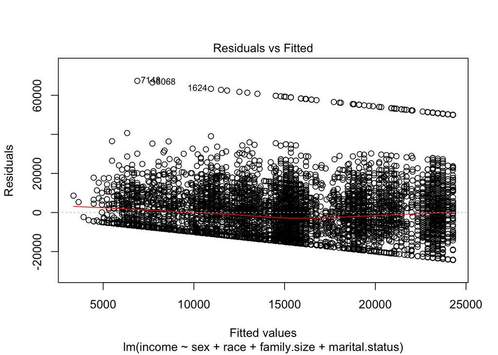

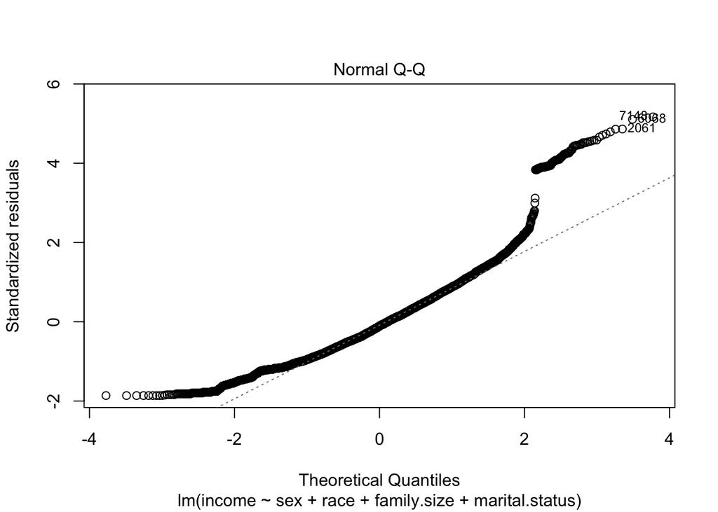

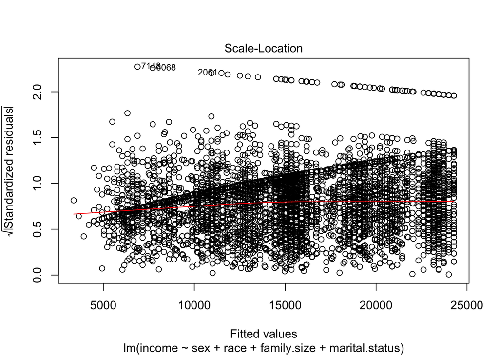

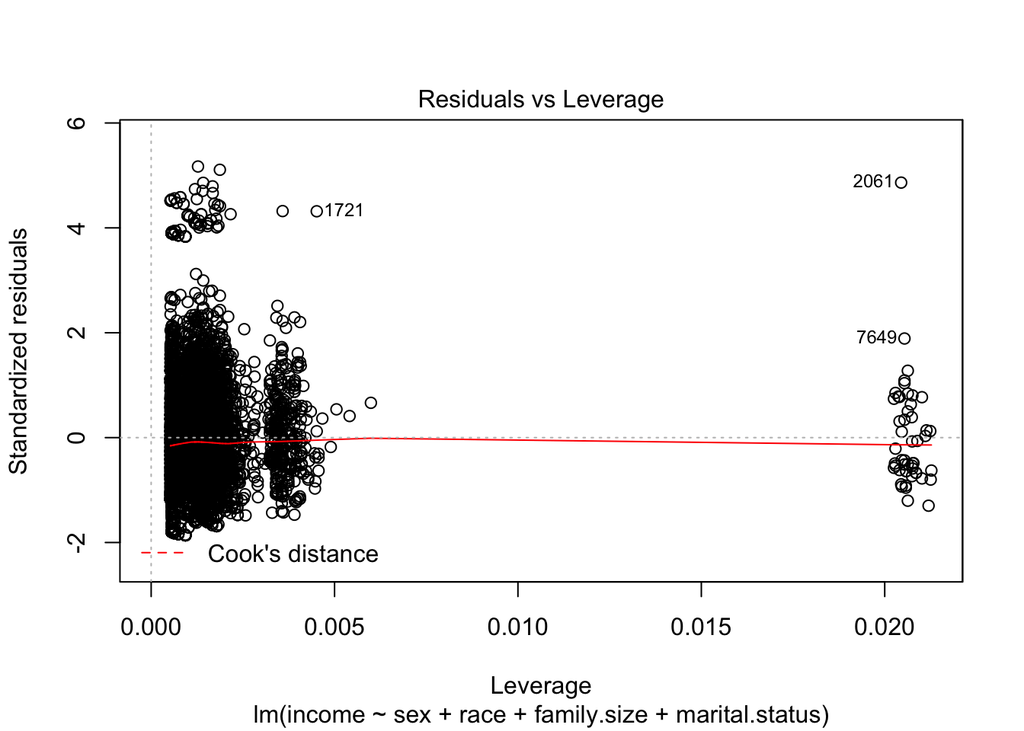

```r
nlsy2.lm2 <- lm(income ~ sex + race + family.size + marital.status , data = nlsy4)
plot(nlsy2.lm2)
```

I made 3 more diagnostic plots for the interactive regression where I consider the impact of race on sex, the impact of family size on sex, and the impact of marital status on sex. All of them show the similar diagnostic plots. Below is the diagnostic plots for the interactive regression where I consider the impact of race on sex. We can see that the plots largely remain unchanged compared with the plots above. So it’s not advisable to use linear regression to build the model, and a non-linear model may be more appropriate.

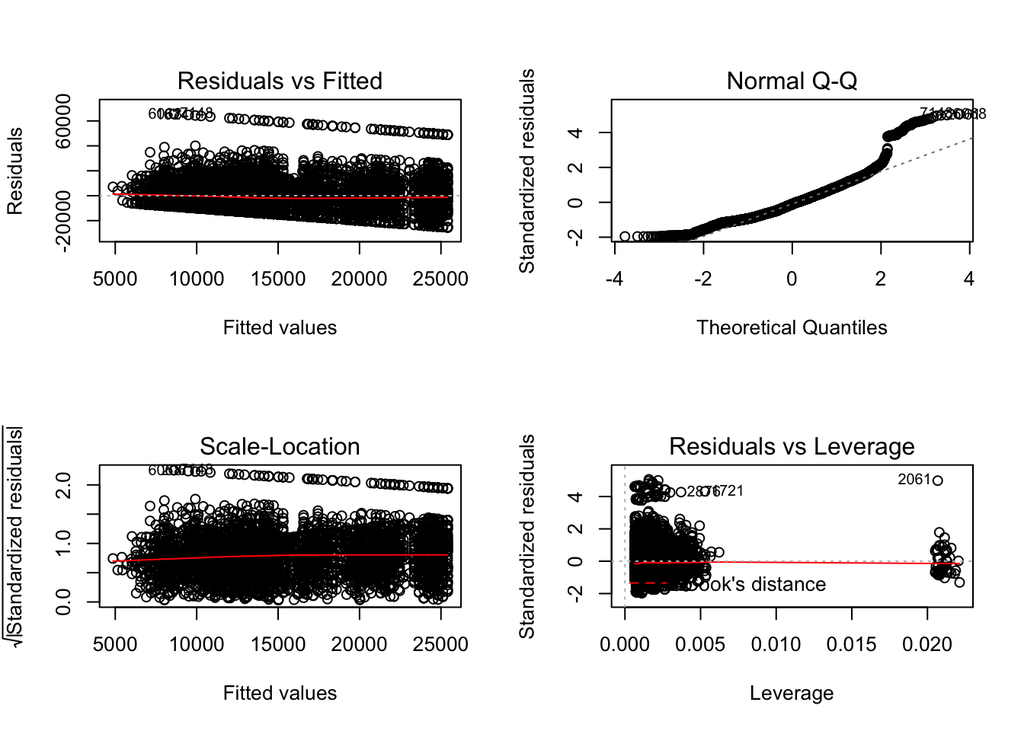

```r
nlsy2.lm3 <- lm(income ~ sex + race + family.size + marital.status + sex * race, data = nlsy4)
par(mfrow=c(2,2))
plot(nlsy2.lm3)
```

Conclusion:

In this project, I want to identify what variables will have impact on the income gap between men and women. At first, I cleaned the original data set by removing rows whose income is less than 0. I found that there’s no missing value in the original data set, and in terms of the invalid values, I mapped them to missing value, and removed or not selected them in the following analysis. Then I constructed bar charts and ran regression models to see what variables will affect the income gap between men and women, and whether it’s significant. I found that according to the t-test, in the 5 different variables I chose (race, family size, marital.status, education, country), race and marital status have significant impact on the income gap between men and women. According to the linear regression, race, family size, and marital.status have significant impact on the income gap between men and women. However, from the diagnostic plots we can see that the it may be not appropriate to use a linear regression model to explain the effects. We should try other models to see which one will explain the effects.

One of the limitations is that when I study whether there’s significant difference in income between men and women, I only control one variable each time, I should try to control all independent variables at the same time. Besides, I didn’t test collinearity in my regression model. Lastly, according to the Scale-location plot, the data demonstrates heteroscedasticity, which indicates we have omitted variable bias.

I don’t have much confidence in my analysis. Although 3 variables seem to be significant when I ran the regression models, and based on common sense they do affect the income gap between men and women, from the diagnostic plots we can see that regression model is not suitable for this analysis. So, this study is not yet resolved and needs to continue to be explored.